# DBDC - Visualización de Datos - Tarea 1

2023

Autor/a

Joshua Kunst

## Consideraciones

- La fecha de entrega es domingo 3 septiembre 2023 a las 23:59.
- La evaluación se puede realizar de a lo más 2 alumnos.
- Para facilitar y agilizar la correción se agradece considerar que el archivo a enviar sea: `eval2_nombre1_nombre2.R` o `eval2_nombre1_nombre2.ipynb`. Ejemplo `eval2_Tulio_Treviño_Carlos_Bodoque.R`.
- Enviar un archivo por grupo a la dirección `jbkunst@gmail.com` con el asunto **DBDC-Viz-2: Nombre1 y Nombre2**. Ejemplo *DBDC-Viz-2: Tulio Treviño y Carlos Bodoque*.
- El archivo debe ser reproducible, en el sentido de quien evalue pueda correr línea a línea, i.e. en orden, sin error los códigos del script.
- La evaluación no se basa solamente en los *outputs* como tablas o gráficos sino también en los argumentos y comentarios realizados.

En esta tarea utilizaremos los siguientes paquetes. Asegúrese de tenerlos instalados previamente.

```r
library(tidyverse)
library(data.table) # fread
```

## Items

### Datos 1

En las siguientes preguntas el dataset a utilizar correponden a datos de movilidad. Estos datos poseen aproximadamente 2,5 millones de registros que representan observaciones desde GPS de dispositivos. En este caso particular solamente de un día y solo para el Gran Santiago.

```r
datos <- data.table::fread("https://github.com/jbkunst/random-data/raw/main/movilidad.gz")
datos <- as_tibble(datos)

glimpse(datos)
```

```
Rows: 2,506,511
Columns: 10
$ comuna            <chr> "Cerrillos", "Cerrillos", "Cerrillos", "Cerrillos", …
$ device_id         <chr> "6e8bd213-50e5-4b03-9dde-eb2763a80157", "be62cc42-34…
$ fecha             <IDate> 2021-03-18, 2021-03-18, 2021-03-18, 2021-03-18, 20…
$ hora              <int> 2, 5, 20, 22, 27, 28, 34, 37, 41, 49, 52, 58, 66, 71…
$ timestamp         <int64> 1616025602000, 1616025605000, 1616025620000, 16160…
$ latitude          <dbl> -33.48380, -33.48983, -33.49933, -33.50529, -33.5168…
$ longitude         <dbl> -70.72506, -70.72457, -70.71428, -70.70352, -70.7151…
$ device_os         <chr> "Android", "Android", "Android", "Android", "Android…
$ device_os_version <chr> "", "", "", "", "", "", "", "", "", "", "", "", "", …
$ geohash           <chr> "66j9w87wf8jm", "66j9qx7gw51q", "66j9qvekmbe9", "66j…
```

Los campos relevantes por el momento son: `comuna` desde donde se realiza la solicitud GPS, `devide_id` que identifica un dispositivo, `timestamp` (marca temporal) que representa una fecha y hora, `latitude` y `longitude` del dispositivo al momento de solicitar la información GPS.

### Item 0 (1 pto.)

Crearemos nuevas columnas para el análisis de los datos.

```r
datos <- datos |>
  arrange(device_id, timestamp) |>
  mutate(
    hora2 = hms::as_hms(as_datetime(timestamp/1000)),
    fecha_hora = as_datetime(timestamp/1000),
    horario = case_when(
      hora2 < hm("6:00")  ~ "Madrugada",
      hora2 < hm("12:00") ~ "Mañana",
      hora2 < hm("19:00") ~ "Tarde",
      hora2 < hm("24:00") ~ "Noche"
      ),
    horario = factor(
      horario,
      levels = c("Madrugada", "Mañana", "Tarde", "Noche")
      )
    )

glimpse(datos)
```

```
Rows: 2,506,511
Columns: 13
$ comuna            <chr> "Pudahuel", "Pudahuel", "Pudahuel", "Pudahuel", "Pud…
$ device_id         <chr> "00025c1e-2b77-4aa5-b334-68e436cb2b00", "00025c1e-2b…
$ fecha             <IDate> 2021-03-18, 2021-03-18, 2021-03-18, 2021-03-18, 20…
$ hora              <int> 64535, 64612, 64658, 64731, 67344, 70786, 70821, 847…
$ timestamp         <int64> 1616090135000, 1616090212000, 1616090258000, 16160…
$ latitude          <dbl> -33.45150, -33.45150, -33.45150, -33.45150, -33.4515…
$ longitude         <dbl> -70.75150, -70.75150, -70.75150, -70.75150, -70.7515…
$ device_os         <chr> "Android", "Android", "Android", "Android", "Android…
$ device_os_version <chr> "", "", "", "", "", "", "", "", "", "", "", "", "", …
$ geohash           <chr> "66j9wn26ftjk", "66j9wn26fkrw", "66j9wn26fkrw", "66j…
$ hora2             <time> 17:55:35, 17:56:52, 17:57:38, 17:58:51, 18:42:24, 1…
$ fecha_hora        <dttm> 2021-03-18 17:55:35, 2021-03-18 17:56:52, 2021-03-1…
$ horario           <fct> Tarde, Tarde, Tarde, Tarde, Tarde, Noche, Noche, Noc…
```

A partir del código y del output de la función `glimpse` describa cada una de las 3 columnas creadas y las funciones requeridas para la obtención de las mismas.

### Item 1 (2 pto.)

Con `ggplot2` genere un histograma de la variable `hora2` y comente el resultado.

Adicionalmente describa el gráfico obtenido en función de:

- *Marcas* y *señales* que se utilizan
- Para que sirve este tipo de visualización (*why?*).

### Item 2 (2 pto.)

Realice el conteo de registros por las variables `comuna` y `horario` de la tabla de `datos` para luego generar un grafico de columna mostrando cantidad de regitros por horario *faceteado* por comuna. Comentar lo observado. ¿Existe alguna comuna que rompa el *patrón* de comportamiento?

### Item 3 (1 pto.)

Obtenga un data frame de 4 filas, cuyos registros sean los 4 dispositivos `device_id` con más comunas registradas (en caso de empates seleccioanar arbitrariamente haste tener 4 dispositivos).

### Grafico 1

Considere el siguiente gráfico llamado `p`:

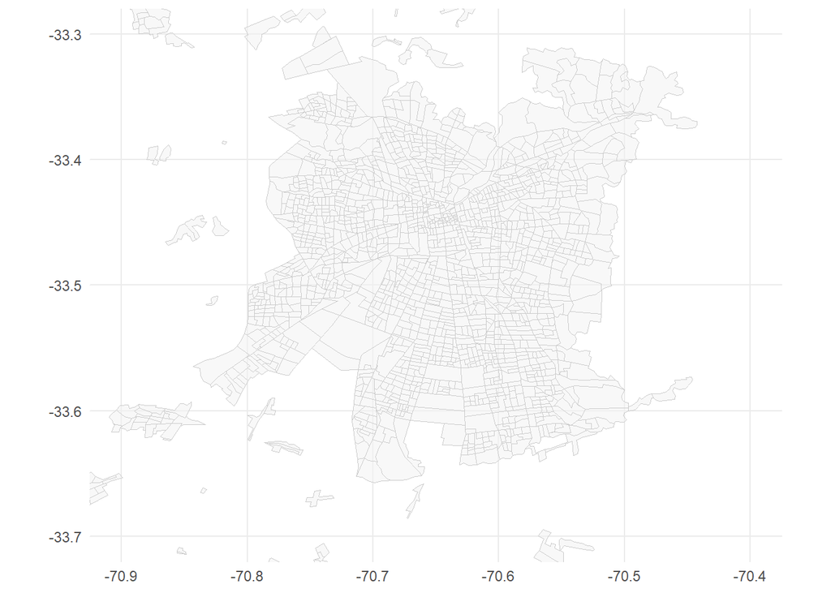

```r
p <- ggplot() +
  geom_sf(
    aes(geometry = geometry),
    data = filter(chilemapas::mapa_zonas, codigo_region == "13"),
    fill = "gray95", color = "gray80", alpha = 0.5, size = 0.3
    ) +
  coord_sf(xlim = c(-70.9, -70.4), ylim = c(-33.3, -33.7)) +
  theme_minimal()

p
```

### Item 4 (2 ptos.)

Considerando el gráfico `p`, agregue una capa `geom_` adecuada para mostrar la ruta de cada uno de los dispositivos del item 3. Utilice `facet_wrap` para realizar *pequeños multiples* de estos 4 dispositivos. Comente lo que observa. ¿Existe alguna ruta común entre estos 4 dispositivos?

### Datos 2

```r
datos2 <- read_csv("https://raw.githubusercontent.com/rivaquiroga/guaguas/main/data-raw/1920-2021.csv")

glimpse(datos2)
```

```
Rows: 858,782
Columns: 5
$ anio       <dbl> 1920, 1920, 1920, 1920, 1920, 1920, 1920, 1920, 1920, 1920,…
$ nombre     <chr> "Aaron", "Abdolina", "Abdon", "Abdón", "Abel", "Abelardo", …
$ sexo       <chr> "M", "F", "M", "M", "M", "M", "F", "M", "F", "M", "M", "F",…
$ n          <dbl> 1, 1, 1, 2, 11, 10, 2, 3, 1, 15, 1, 1, 3, 2, 1, 1, 10, 1, 9…
$ proporcion <dbl> 0.00004906, 0.00004906, 0.00004906, 0.00009812, 0.00053967,…
```

### Item 4 (1 pto.)

Considerando el(los) nombre(s) de los integrantes realice un gráfico que muestre/describa la popularidad de dicho(s) nombre(s) durante el tiempo. ¿Antes de graficar, explique/argumente por que usará dicha geometría (`geom_`)? ¿Ve algún patrón o comportamiento inusual en los datos?

### Item 5 (1 pto.)

Replique el ejercicio anterior pero con el nombre *Brian* y considere sus variaciones como *Bryan*, *Braian* o su alternativa *Brayan* e incluso una menos usual como *Brallan*. ¿Comente que observa? ¿Existe algún patrón que pueda ser explicado por algún evento histórico?